# Proyecto 2: Series de Tiempo

7/6/2020

## Datos

Los datos se tomaron de la página: https://machinelearningmastery.com/time-series-seasonality-with-python/

- Son temperaturas mínimas diarias
- Ciudad de Melbourne, Australia (1981-1990)

## Visualización de los datos

Datos previos a las transformaciones.

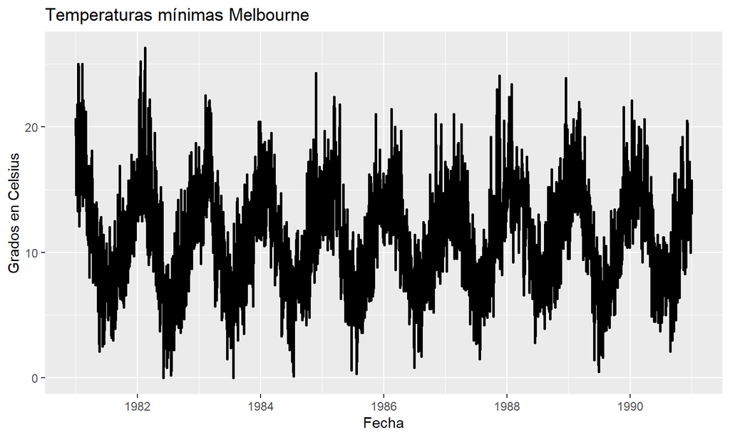

## Outliers

Antes de hacer algún ajuste o transformación queríamos identificar los outliers de nuestra serie.

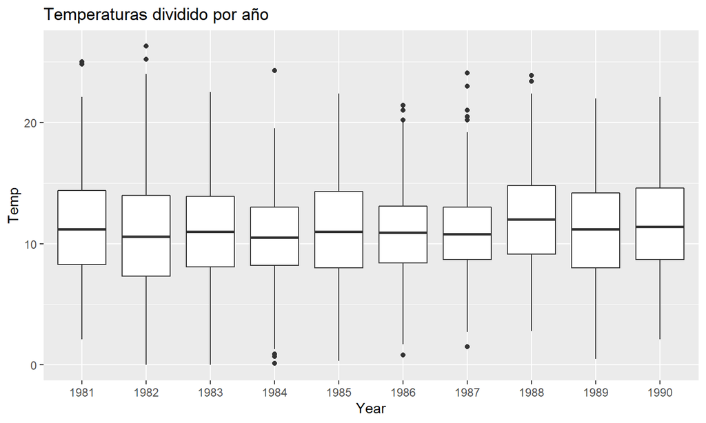

## Ajuste de Calendario Mensual

Agrupamos mensualmente los datos sacando el promedio mensual.

|  | Month | AvTemp |
| --- | --- | --- |
| 1 | 1981-01-01 | 17.7129032258064 |
| 2 | 1981-02-01 | 17.6785714285714 |
| 3 | 1981-03-01 | 13.5 |
| 4 | 1981-04-01 | 12.3566666666667 |
| 5 | 1981-05-01 | 9.49032258064516 |
| 6 | 1981-06-01 | 7.30666666666667 |
| 7 | 1981-07-01 | 7.57741935483871 |
| 8 | 1981-08-01 | 7.23870967741935 |
| 9 | 1981-09-01 | 10.1433333333333 |
| 10 | 1981-10-01 | 10.0870967741935 |

[output cut: 110 more lines]

## Temperaturas mínimas Mensuales Melbourne

Datos después del ajuste de calendario.

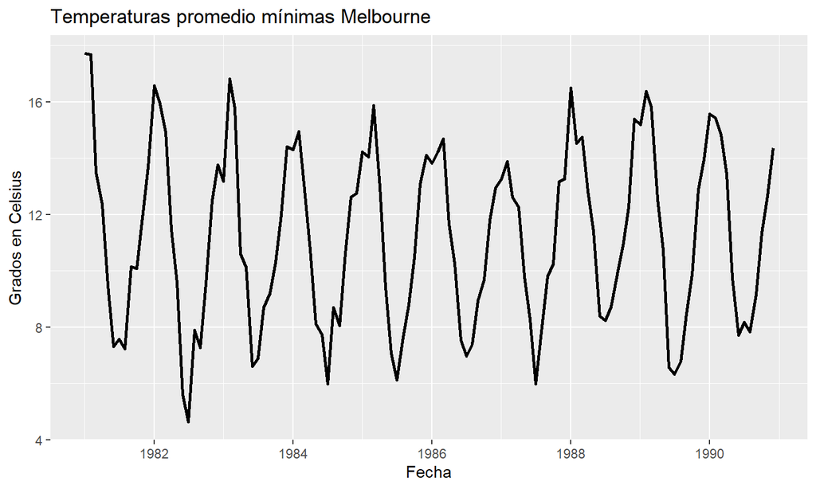

## Descomposición

Estacionalidad marcada.

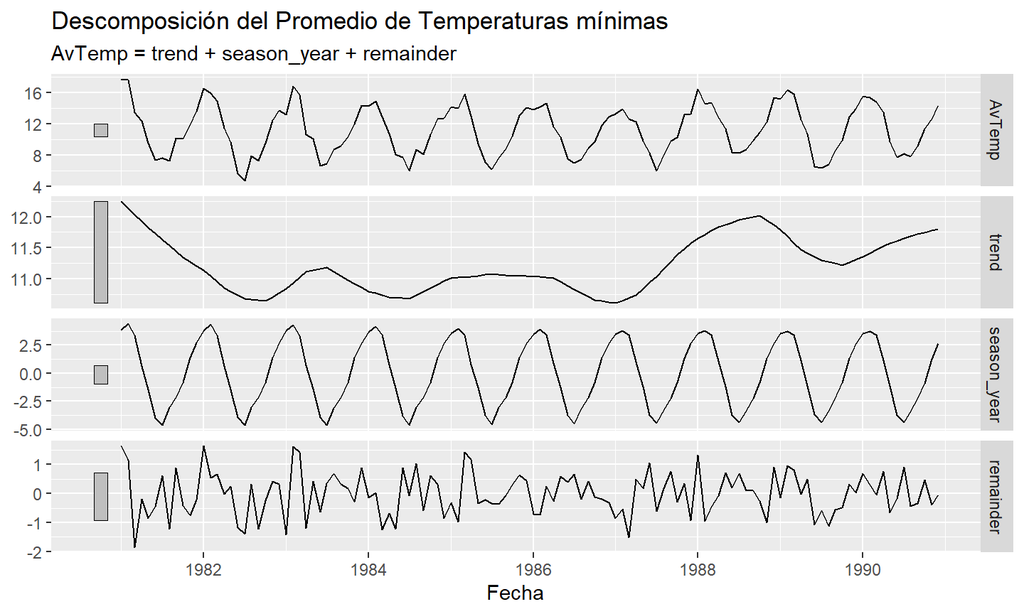

## Box-Cox

Hicimos la transformación Box-Cox para reducir un poco el tamaño de la variación estacional a lo largo de la serie. Lo realizamos con la función de guerrero.

## SES

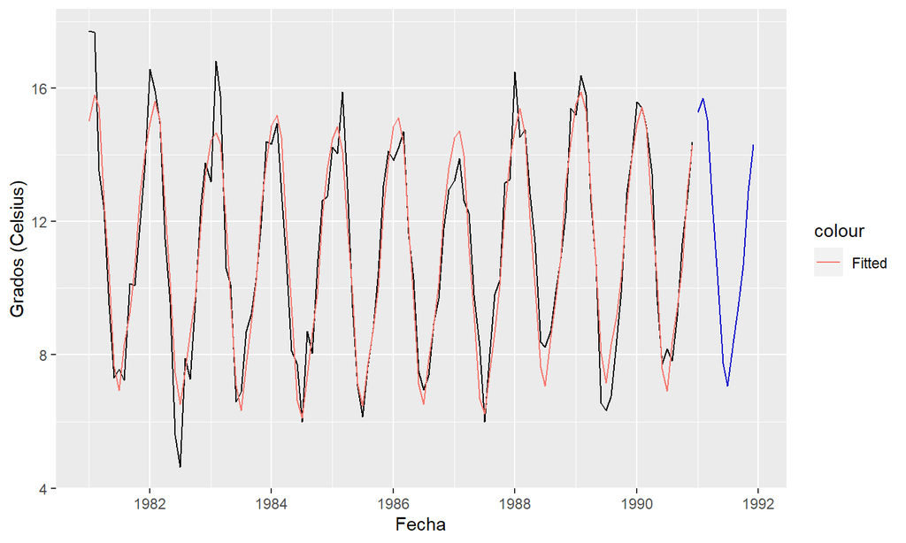

## Holt

Tendencia a la baja para el final de ese año.

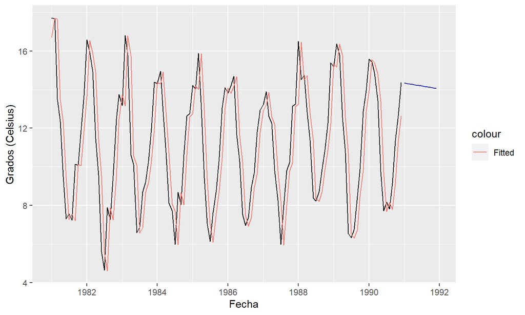

## Damped Holt

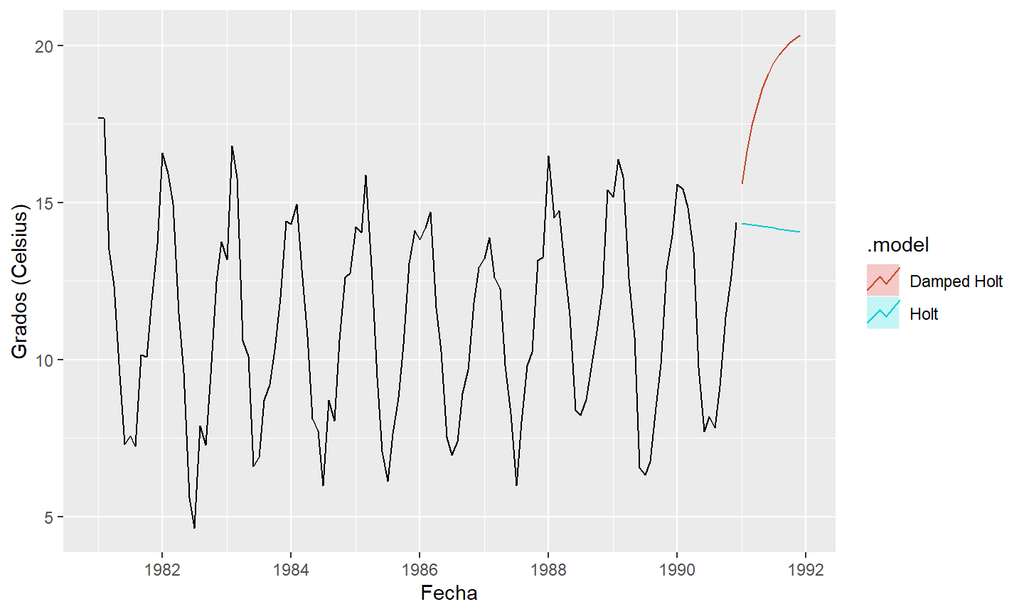

## Holt Winters

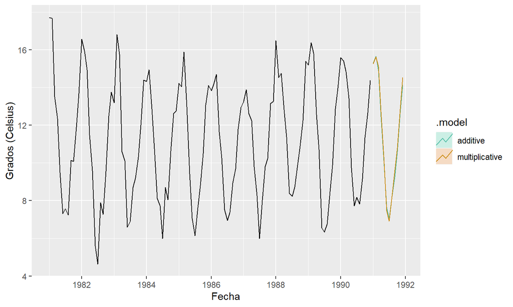

## Holt Winters Amortiguado

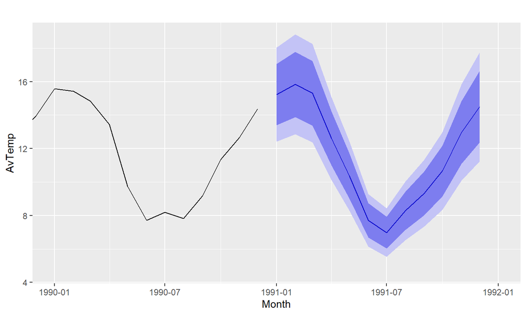

## Métodos de referencia

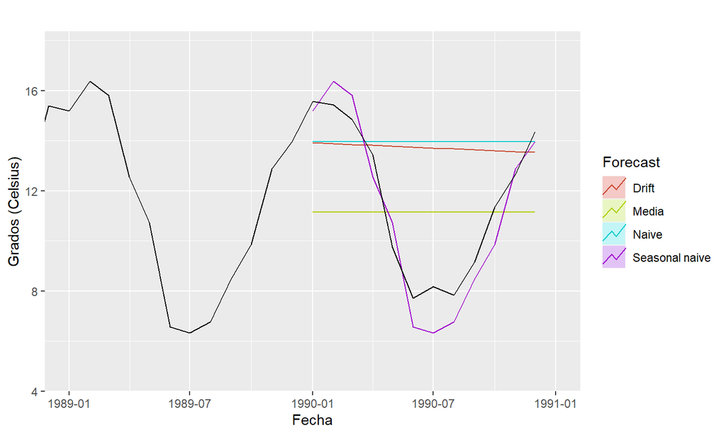

## Comparación de Pronósticos

Esta comparación nos ayuda a ver la diferencia entre los modelos y cuáles son los que mejor se ajustan.

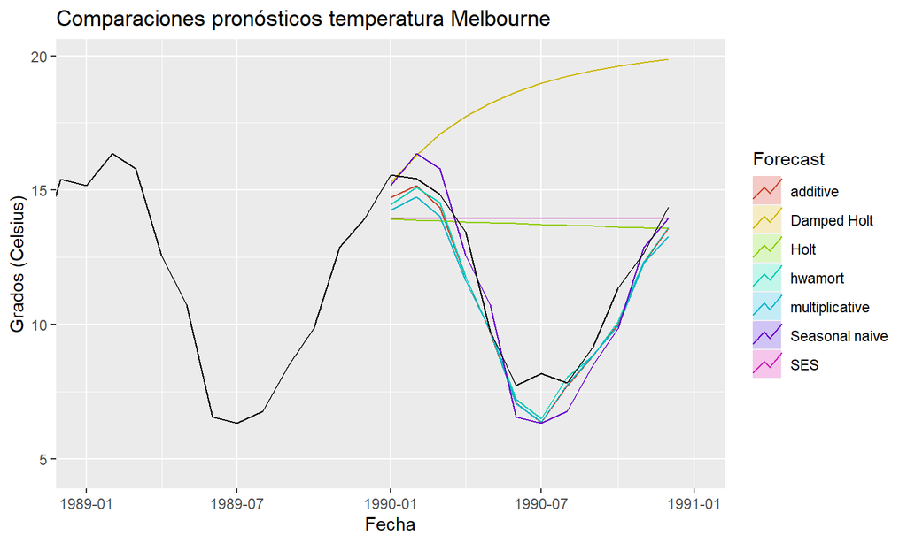

## Accuracy

Con la función de accuracy podemos ver qué tanto se ajustan los modelos o qué tan buenos son los modelos para la serie de tiempo.

|  | .model | RMSE | MAE | MPE | MAPE | MASE | ACF1 |
| --- | --- | --- | --- | --- | --- | --- | --- |
| 1 | hwamort | 0.894477605835997 | 0.70224471842105 | 5.85860645531259 | 6.31310390350236 | 0.650047744327189 | -0.500892794184206 |
| 2 | additive | 0.921423141219192 | 0.724421855297361 | 6.59737879967497 | 6.59737879967497 | 0.670576482278392 | -0.449063072562926 |
| 3 | Seasonal naive | 1.01935386590916 | 0.918792242703533 | 4.91814939459794 | 8.99693184681384 | 0.850499561203746 | 0.130647090576628 |
| 4 | multiplicative | 1.04899957034696 | 0.859516517245989 | 7.46658076468387 | 7.46658076468387 | 0.795629726491893 | -0.448923305779649 |
| 5 | Holt | 3.55072906128132 | 2.88261899247348 | -25.7882592811396 | 31.2403605614868 | 2.668357517911 | 0.734515790440238 |
| 6 | SES | 3.70437725662164 | 2.99371926976765 | -27.7534668359744 | 32.5541225050493 | 2.77119985015607 | 0.739357627250301 |
| 7 | Damped Holt | 7.73872405548761 | 6.71307547502736 | -69.794521215096 | 70.1019212228892 | 6.21410094738977 | 0.75645976340631 |

## Pronóstico

El mejor modelo para nuestra serie de acuerdo con el RMSE es el Holt Winters Amortiguado.

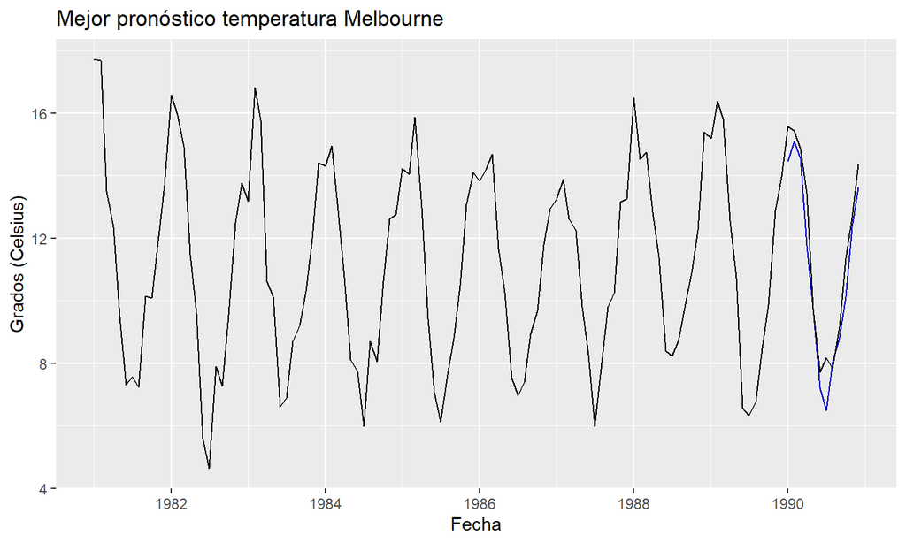

## Interpretaciones

- Todos los modelos nos ayudaron a tomar una decisión sobre el modelo más adecuado
- Gracias a la estacionalidad de la serie fue fácil realizar un pronóstico más acertado
- Variaciones mínimas
- Predicción bastante buena y válida para la temperatura del año próximo